# 2 Regression and model validation

```
Intro from the IODS MOOC-page:
```

How to predict values of one random variable based on information from other variables? This is a basic question behind a **statistical model**, where we try to reveal something about the **causal relation** between different matters of life on Earth - or in the Universe. **Regression analysis** has its roots in the early 19th century, and it is still going strong!

There are dozens of variations of the **regression model**, depending on the types of variables, the nature of the data, and the research design. We start from the **simple linear regression** and proceed to its extended form, the **multiple linear regression**. In addition, we check the validity of the assumptions that we make about the model(s), by investigating the so called model diagnostics.

## 2.1 Introducing the dataset

The background of the data as described by the author:

> Kimmo Vehkalahti: ASSIST 2014 - Phase 3 (end of Part 2), N=183 Course: Johdatus yhteiskuntatilastotieteeseen, syksy 2014 (Introduction to Social Statistics, fall 2014 - in Finnish), international survey of Approaches to Learning, made possible by Teachers’ Academy funding for KV in 2013-2015.

> Data collected: 3.12.2014 - 10.1.2015/KV Data created: 14.1.2015/KV, in English 9.4.2015/KV,Florence,Italy Imputation 4.4.2015: only missing information in certain backgrounds, minimal amount of missing values imputed using Phases 1 and 2.

> For more information, see https://www.mv.helsinki.fi/home/kvehkala/JYTmooc/JYTOPKYS3-meta.txt

```r
learning2014 <- read.csv("./data/learning2014.csv") # reading the analysis data
learning2014$gender <- as.factor(learning2014$gender) # change to factor
dim(learning2014) # number of rows and columns
```

```
## [1] 166   7
```

```r
str(learning2014) # type of data
```

```
## 'data.frame':    166 obs. of  7 variables:
##  $ gender  : Factor w/ 2 levels "F","M": 1 2 1 2 2 1 2 1 2 1 ...
##  $ age     : int  53 55 49 53 49 38 50 37 37 42 ...
##  $ attitude: num  3.7 3.1 2.5 3.5 3.7 3.8 3.5 2.9 3.8 2.1 ...
##  $ deep    : num  3.58 2.92 3.5 3.5 3.67 ...
##  $ stra    : num  3.38 2.75 3.62 3.12 3.62 ...
##  $ surf    : num  2.58 3.17 2.25 2.25 2.83 ...
##  $ points  : int  25 12 24 10 22 21 21 31 24 26 ...
```

The learning dataset used in this exercise consists of 166 observations and 7 variables. Variables `deep`, `stra` and `surf` were calculated based on several Likert scale questions (from 1 to 5). Variable names and short descriptions:

1. gender - Gender: M (Male), F (Female)
2. age - Age (in years) derived from the date of birth
3. attitude - Global attitude toward statistics
4. deep - Tendency to deep learnign
5. stra - Tendency to strategic learning
6. surf - Tendency to surface learning
7. points - Exam points

## 2.2 Graphical overview and summary of the data

To get the idea of the data, let’s make a graphical summary of the variables with females (red) and males (blue):

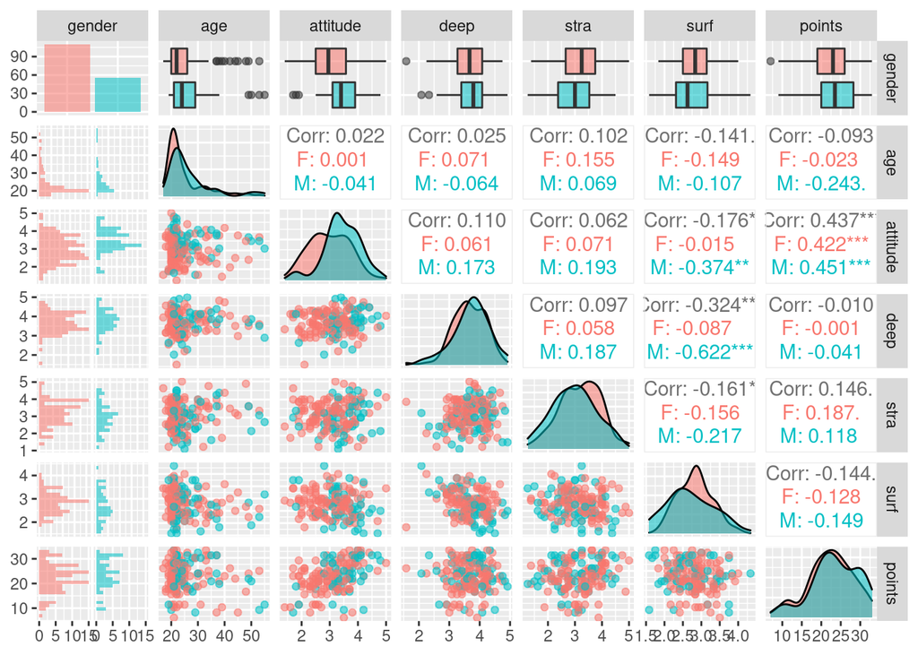

```r
library(ggplot2);
library(GGally);
p <- ggpairs(learning2014, mapping = aes(col=gender, alpha=0.3), lower = list(combo = wrap("facethist", bins = 20)), upper = list(continuous = wrap("cor", family="sans")))
p # graphical summary
```

```r
summary(learning2014) # numerical summary
```

```
##  gender       age           attitude          deep            stra
##  F:110   Min.   :17.00   Min.   :1.400   Min.   :1.583   Min.   :1.250
##  M: 56   1st Qu.:21.00   1st Qu.:2.600   1st Qu.:3.333   1st Qu.:2.625
##          Median :22.00   Median :3.200   Median :3.667   Median :3.188
##          Mean   :25.51   Mean   :3.143   Mean   :3.680   Mean   :3.121
##          3rd Qu.:27.00   3rd Qu.:3.700   3rd Qu.:4.083   3rd Qu.:3.625
##          Max.   :55.00   Max.   :5.000   Max.   :4.917   Max.   :5.000
##       surf           points
##  Min.   :1.583   Min.   : 7.00
##  1st Qu.:2.417   1st Qu.:19.00
##  Median :2.833   Median :23.00
##  Mean   :2.787   Mean   :22.72
##  3rd Qu.:3.167   3rd Qu.:27.75
##  Max.   :4.333   Max.   :33.00
```

Taking a look at the graphical overview, the distribution for female (red) and male (blue) values seems to be relatively similar in all categories. Females seem to have a slightly higher values in surface learning (surf) and strategic learning (stra) and slighly lower values in attitude. The numerical summary of all data (not filtered by gender) shows that the majority of participants is young (under 30 years of age).

## 2.3 Fitting a regression model

Next, let’s test if there is correlation between attitude, strategic learning (`stra`) and surface learning tendency (`surf`) with the number of points obtained from the exam:

```r
library(ggplot2)
# create a regression model with multiple explanatory variables
my_model <- lm(points ~ attitude + stra + surf, data = learning2014)
# print out a summary of the model
summary(my_model)
```

```
##
## Call:
## lm(formula = points ~ attitude + stra + surf, data = learning2014)
##
## Residuals:
##      Min       1Q   Median       3Q      Max
## -17.1550  -3.4346   0.5156   3.6401  10.8952
##
## Coefficients:
##             Estimate Std. Error t value Pr(>|t|)
## (Intercept)  11.0171     3.6837   2.991  0.00322 **
## attitude      3.3952     0.5741   5.913 1.93e-08 ***
## stra          0.8531     0.5416   1.575  0.11716
## surf         -0.5861     0.8014  -0.731  0.46563
## ---
## Signif. codes:  0 '***' 0.001 '**' 0.01 '*' 0.05 '.' 0.1 ' ' 1
##
## Residual standard error: 5.296 on 162 degrees of freedom
## Multiple R-squared:  0.2074, Adjusted R-squared:  0.1927
## F-statistic: 14.13 on 3 and 162 DF,  p-value: 3.156e-08
```

Coefficients table gives an interpretation of the model. Intercept giving the “baseline” for the points in exam, it seems that attitude has the biggest correlation between exam points. If attitude rises one unit, then exam points increase by 3.4 units given that all other variables stay the same. The effect of `stra` and `surf` is below one. The importance of `attitude` can also be seen in the last column where the statistical significance of the coefficient is given. The three stars *** indicate high statistical significance, i.e. the coefficient differs from zero and thus has a relationship with the target variable. In general, the P-test value shown here tells the propability of the coefficient being zero.

Let’s drop `surf` (highest propability) to see if it improves the fitting:

```r
# create a regression model with multiple explanatory variables
my_model2 <- lm(points ~ attitude + stra, data = learning2014)
# print out a summary of the model
summary(my_model2)
```

```
##
## Call:
## lm(formula = points ~ attitude + stra, data = learning2014)
##
## Residuals:
##      Min       1Q   Median       3Q      Max
## -17.6436  -3.3113   0.5575   3.7928  10.9295
##
## Coefficients:
##             Estimate Std. Error t value Pr(>|t|)
## (Intercept)   8.9729     2.3959   3.745  0.00025 ***
## attitude      3.4658     0.5652   6.132 6.31e-09 ***
## stra          0.9137     0.5345   1.709  0.08927 .
## ---
## Signif. codes:  0 '***' 0.001 '**' 0.01 '*' 0.05 '.' 0.1 ' ' 1
##
## Residual standard error: 5.289 on 163 degrees of freedom
## Multiple R-squared:  0.2048, Adjusted R-squared:  0.1951
## F-statistic: 20.99 on 2 and 163 DF,  p-value: 7.734e-09
```

Leaving out surface learning increases the significance of the remaining variables (decreased values in P-value column). However, the value for strategic learning (`stra`) is still relatively high (debatable). As it is less than < 0.10, let’s keep it in the model. So we have found our final model.

## 2.4 Analyzing the fitted model

Our final model is thus

> exam points = 8.97 + 3.47 x attitude + 0.91 x stra

This means that with one unit increase in attitude exam points increase by 3.47 points (stra being unchanged) and with one unit increase in strategic learning (`stra`) the exam points increase by 0.91. The baseline for exam points is 8.97 (the y-intercept). Now this is the systemic part (no error).

The numbers at the end of the multiple regression summary can be explained succinctly as:

- **Residual Standard Error**: Standard deviation of residuals / errors of the regression model.
- **Multiple R-Squared**: Percent of the variance of *exam* intact after subtracting the error of the model.
- **Adjusted R-Squared**: Same as multiple R-Squared but takes into account the number of samples and variables.

So adjusted R-squared tells how well the model fits the data, i.e. the percentage of the dependent variable variation that the linear model explains (ranging between 0 and 1). The R-squared seen here (roughly 0.20) is quite low so there is probably some problematic patterns in the residual plots. At least the residuals are not very close to the regression line. That’s why you cannot rely on the R-squared number alone but a visual inspection is a must!

## 2.5 Model validity and diagnostic plots

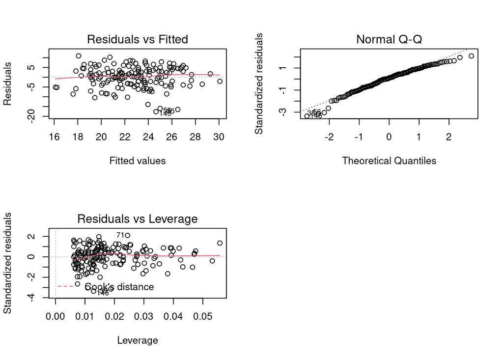

```r
# drawing diagnostic plots using the plot() function. Choose the plots 1, 2 and 5:
par(mfrow = c(2,2))
plot(my_model2, which=c(1,2,5))
```

A statistical model always include **assumptions** which describe the data generation process. In this linear regression case we assume

- **linearity**, i.e. the target variable can be modelled as a linear combination of the model parameters
- the **errors** are normally distributed, are not correlated and have constant variance (the size of the given error does not depend on the explanatory variables)

These assumptions can be checked through analyzing residuals.

- **Residuals vs. model predictions i.e. fitted values**: for analyzing constant variance of errors. “Any pattern in the plot implies a problem with the assumptions.”
- **QQ-plot**: for analyzing the normality of errors. “The better residuals are located on the identity line, the better the normality assumption holds.”
- **Leverage**: for analyzing the impact of a single observation on the model. “The outliers have high impact.”

In residuals vs. fitted we can see the source of the low R-squared value: the residuals are not very close to the regression line (note y-axis scale). However, they seem to describe the trend in observations well since there is no noticeable pattern. QQ-plot also shows that the residuals are nicely located on the line, i.e. the normality assumption holds. Residuals vs. leverage shows some points at the right hand side of the plot but the x-axis scaling (max leverage value of 0.05) is still quite small, so no problems here either. All in all, it seems our multiple regression model nicely describes the data and all the assumptions hold.

With the model validated, now we could use our regression model to **predict** the target variable behavior!